# Pie Charts, Box Plots, Scatter Plots, and Bubble Plots

## What I'm Doing

Using Matplotlib and pandas, I load and visualize Canadian immigration data (1980–2013) with pie, box, scatter, and bubble plots to highlight trends, compare distributions, and fit regression lines for predictions

## 1. Setting Up

First, I import the core libraries and set up Matplotlib with a clean visual style.

```
import numpy as np
import pandas as pd
import matplotlib as mpl
import matplotlib.pyplot as plt

mpl.style.use('ggplot')
print('Matplotlib version:', mpl.__version__)
```

```
Matplotlib version:  3.10.9
```

Now I load the Canadian immigration dataset from the provided URL.

```
df_can = pd.read_csv(
    'https://cf-courses-data.s3.us.cloud-object-storage.appdomain.cloud/IBMDeveloperSkillsNetwork-DV0101EN-SkillsNetwork/Data%20Files/Canada.csv')
```

## 2. Getting to Know the Dataset

Let's check what we're working with.

```
df_can.head()
```

|  | Country | Continent | Region | DevName | 1980 | 1981 | 1982 | 1983 | 1984 | 1985 | ... | 2005 | 2006 | 2007 | 2008 | 2009 | 2010 | 2011 | 2012 | 2013 | Total |
| --- | --- | --- | --- | --- | --- | --- | --- | --- | --- | --- | --- | --- | --- | --- | --- | --- | --- | --- | --- | --- | --- |
| 0 | Afghanistan | Asia | Southern Asia | Developing regions | 16 | 39 | 39 | 47 | 71 | 340 | ... | 3436 | 3009 | 2652 | 2111 | 1746 | 1758 | 2203 | 2635 | 2004 | 58639 |
| 1 | Albania | Europe | Southern Europe | Developed regions | 1 | 0 | 0 | 0 | 0 | 0 | ... | 1223 | 856 | 702 | 560 | 716 | 561 | 539 | 620 | 603 | 15699 |
| 2 | Algeria | Africa | Northern Africa | Developing regions | 80 | 67 | 71 | 69 | 63 | 44 | ... | 3626 | 4807 | 3623 | 4005 | 5393 | 4752 | 4325 | 3774 | 4331 | 69439 |
| 3 | American Samoa | Oceania | Polynesia | Developing regions | 0 | 1 | 0 | 0 | 0 | 0 | ... | 0 | 1 | 0 | 0 | 0 | 0 | 0 | 0 | 0 | 6 |
| 4 | Andorra | Europe | Southern Europe | Developed regions | 0 | 0 | 0 | 0 | 0 | 0 | ... | 0 | 1 | 1 | 0 | 0 | 0 | 0 | 1 | 1 | 15 |

5 rows × 39 columns

Let's find out how many entries there are in our dataset.

```
print(df_can.shape)
```

```
(195, 39)
```

The dataset has **195 countries** (rows) and **39 columns**

### Setting the Country as Index

For quick lookups, I'll set the `Country` column as the index.

```
df_can.set_index('Country', inplace=True)
df_can.head()
```

| Country | Continent | Region | DevName | 1980 | 1981 | 1982 | 1983 | 1984 | 1985 | 1986 | ... | 2005 | 2006 | 2007 | 2008 | 2009 | 2010 | 2011 | 2012 | 2013 | Total |
| --- | --- | --- | --- | --- | --- | --- | --- | --- | --- | --- | --- | --- | --- | --- | --- | --- | --- | --- | --- | --- | --- |
| Afghanistan | Asia | Southern Asia | Developing regions | 16 | 39 | 39 | 47 | 71 | 340 | 496 | ... | 3436 | 3009 | 2652 | 2111 | 1746 | 1758 | 2203 | 2635 | 2004 | 58639 |
| Albania | Europe | Southern Europe | Developed regions | 1 | 0 | 0 | 0 | 0 | 0 | 1 | ... | 1223 | 856 | 702 | 560 | 716 | 561 | 539 | 620 | 603 | 15699 |
| Algeria | Africa | Northern Africa | Developing regions | 80 | 67 | 71 | 69 | 63 | 44 | 69 | ... | 3626 | 4807 | 3623 | 4005 | 5393 | 4752 | 4325 | 3774 | 4331 | 69439 |
| American Samoa | Oceania | Polynesia | Developing regions | 0 | 1 | 0 | 0 | 0 | 0 | 0 | ... | 0 | 1 | 0 | 0 | 0 | 0 | 0 | 0 | 0 | 6 |
| Andorra | Europe | Southern Europe | Developed regions | 0 | 0 | 0 | 0 | 0 | 0 | 2 | ... | 0 | 1 | 1 | 0 | 0 | 0 | 0 | 1 | 1 | 15 |

5 rows × 38 columns

Country names now serve as indices. I then check the dimension to confirm and create list of years for data visualization.

```
print('data dimensions:', df_can.shape)

years = list(map(str, range(1980, 2014)))
```

```
data dimensions: (195, 38)
```

## 3. Pie Charts

A **pie chart** displays **numeric proportions** by dividing a **circle into proportional slices**. It's a go-to visualization for showing parts of a whole.

I'll use a pie chart to explore the proportion of new immigrants grouped by continent across the entire 1980–2013 period.

### Step 1: Gather Data with `groupby`

[figure not shown]

The `groupby` method splits the data into continent groups, applies a sum function, and combines the results. (another functions are: **.sum() .count() .mean() .std() .aggregate() .apply()** .etc..)

```
df_continents = df_can.groupby('Continent', axis=0).sum()
df_continents.head()
```

| Continent | Region | DevName | 1980 | 1981 | 1982 | 1983 | 1984 | 1985 | 1986 | 1987 | ... | 2005 | 2006 | 2007 | 2008 | 2009 | 2010 | 2011 | 2012 | 2013 | Total |
| --- | --- | --- | --- | --- | --- | --- | --- | --- | --- | --- | --- | --- | --- | --- | --- | --- | --- | --- | --- | --- | --- |
| Africa | Northern AfricaMiddle AfricaWestern AfricaSout... | Developing regionsDeveloping regionsDeveloping... | 3951 | 4363 | 3819 | 2671 | 2639 | 2650 | 3782 | 7494 | ... | 27523 | 29188 | 28284 | 29890 | 34534 | 40892 | 35441 | 38083 | 38543 | 618948 |
| Asia | Southern AsiaWestern AsiaWestern AsiaWestern A... | Developing regionsDeveloping regionsDeveloping... | 31025 | 34314 | 30214 | 24696 | 27274 | 23850 | 28739 | 43203 | ... | 159253 | 149054 | 133459 | 139894 | 141434 | 163845 | 146894 | 152218 | 155075 | 3317794 |
| Europe | Southern EuropeSouthern EuropeWestern EuropeEa... | Developed regionsDeveloped regionsDeveloped re... | 39760 | 44802 | 42720 | 24638 | 22287 | 20844 | 24370 | 46698 | ... | 35955 | 33053 | 33495 | 34692 | 35078 | 33425 | 26778 | 29177 | 28691 | 1410947 |
| Latin America and the Caribbean | CaribbeanSouth AmericaCaribbeanCaribbeanCentra... | Developing regionsDeveloping regionsDeveloping... | 13081 | 15215 | 16769 | 15427 | 13678 | 15171 | 21179 | 28471 | ... | 24747 | 24676 | 26011 | 26547 | 26867 | 28818 | 27856 | 27173 | 24950 | 765148 |
| Northern America | Northern AmericaNorthern America | Developed regionsDeveloped regions | 9378 | 10030 | 9074 | 7100 | 6661 | 6543 | 7074 | 7705 | ... | 8394 | 9613 | 9463 | 10190 | 8995 | 8142 | 7677 | 7892 | 8503 | 241142 |

5 rows × 37 columns

### Step 2: Plot a Basic Pie Chart

- `autopct` - is a string or function used to label the wedges with their numeric value. The label will be placed inside the wedge. If it is a format string, the label will be `fmt%pct`.
- `startangle` - rotates the start of the pie chart by angle degrees counterclockwise from the x-axis.
- `shadow` - Draws a shadow beneath the pie (to give a 3D feel).

```
df_continents['Total'].plot(
    kind='pie',
    figsize=(5, 6),
    autopct='%1.1f%%',
    startangle=90,
    shadow=True,
)

plt.title('Immigration to Canada by Continent [1980 - 2013]')
plt.axis('equal')
plt.legend(labels=df_continents.index, loc='upper left')
plt.show()
```

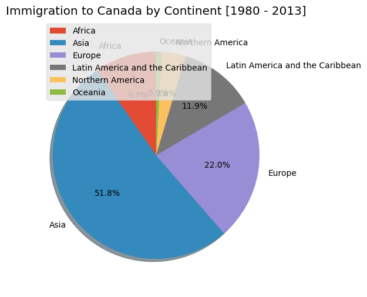

**Result:** A pie chart appears, but the labels and percentages overlap in places. Time to clean it up.

### Step 3: Refine the Pie Chart

```
colors_list = ['gold', 'yellowgreen', 'lightcoral', 'lightskyblue', 'lightgreen', 'pink']
explode_list = [0.1, 0, 0, 0, 0.1, 0.1] # ratio for each continent with which to offset each wedge.

df_continents['Total'].plot(
    kind='pie',
    figsize=(10, 6),
    autopct='%1.1f%%',
    startangle=90,
    shadow=True,
    labels=None,
    pctdistance=1.12,
    # the ratio between the pie center and start of text label generated by autopct
    #colors=colors_list,  # add custom colors
    #explode=explode_list # 'explode' lowest 3 continents
)

# scale the title up by 12% to match pctdistance
plt.title('Immigration to Canada by Continent [1980 - 2013]', y=1.12, fontsize=15)
plt.axis('equal')
plt.legend(labels=df_continents.index, loc='upper left', fontsize=7)
plt.show()
```

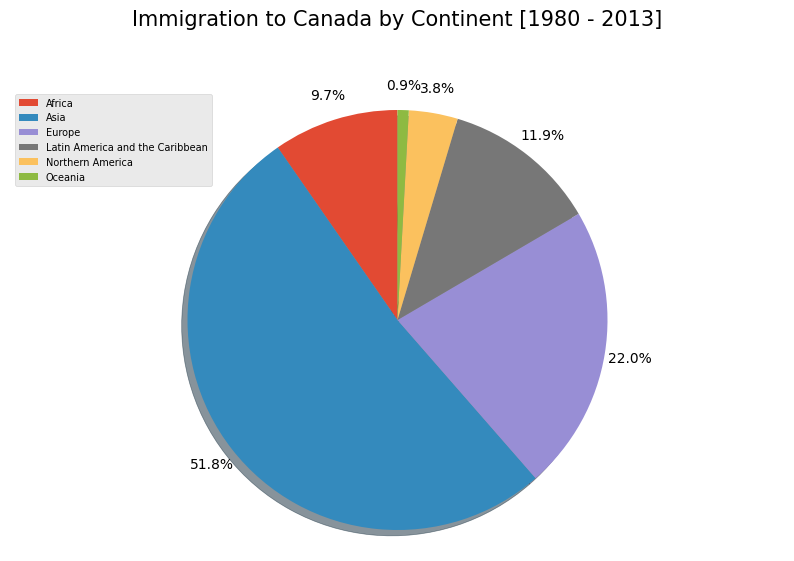

**Result:** A clean, readable pie chart. The percentages sit outside the wedges, and a separate legend identifies each continent. **Europe** and **Asia** dominate, while **Oceania** and **North America** are the smallest slices.

### Exercise: Immigration by Continent in 2013

**Goal:** Create a pie chart showing the proportion of new immigrants grouped by continent, but only for the year **2013**.

```
explode_list = [0.0, 0, 0, 0.1, 0.1, 0.2]

df_continents['2013'].plot(
    kind='pie',
    figsize=(15, 6),
    autopct='%1.1f%%',
    startangle=90,
    shadow=True,
    labels=None,
    pctdistance=1.12,
    # the ratio between the pie center and start of text label
    explode=explode_list,# 'explode' lowest 3 continents
)

plt.title('Immigration to Canada by Continent in 2013', y=1.12)
plt.axis('equal')
plt.legend(labels=df_continents.index, loc='upper left')
plt.show()
```

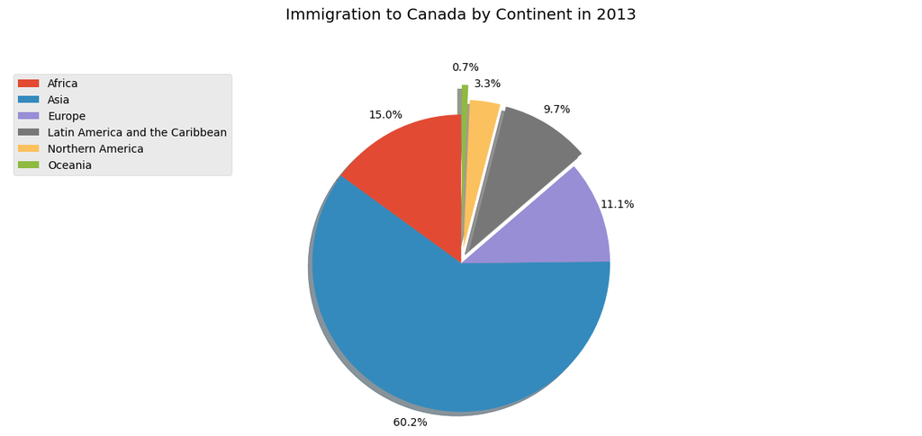

**Result:** A pie chart for 2013 with the smallest continents (Oceania, Northern America, and Latin America & the Caribbean) exploded outward for emphasis.

## 4. Box Plots

A **box plot** summarizes a dataset's distribution through five key statistics: **minimum**, **first quartile (Q1)**, **median (Q2**), **third quartile (Q3)**, and **maximum**. It's **excellent for spotting outliers** and comparing distributions side by side.

[figure not shown]

### Box Plot for Japanese Immigration (1980–2013)

**Step 1:** Extract Japan's data as a transposed dataframe.

```
df_japan = df_can.loc[['Japan'], years].transpose()
df_japan.head()
```

| Country | Japan |
| --- | --- |
| 1980 | 701 |
| 1981 | 756 |
| 1982 | 598 |
| 1983 | 309 |
| 1984 | 246 |

**Step 2:** Plot the box plot.

```
df_japan.plot(kind='box', figsize=(8, 6)) # kind='box'
plt.title('Box plot of Japanese Immigrants from 1980 - 2013')
plt.ylabel('Number of Immigrants')
plt.show()
```

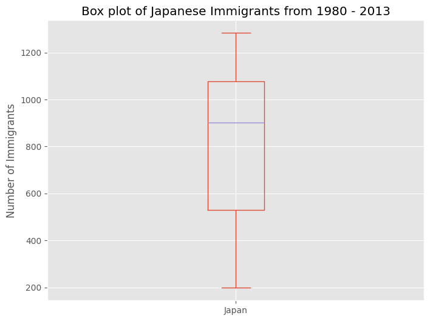

**Result:** A vertical box plot showing:

- **Minimum** ≈ 200 immigrants
- **Maximum** ≈ 1,300 immigrants
- **Median** ≈ 900 immigrants
- **Q1** (~25th percentile) ≈ 500 immigrants
- **Q3** (~75th percentile) ≈ 1,100 immigrants

```
df_japan.describe()
```

| Country | Japan |
| --- | --- |
| count | 34.000000 |
| mean | 814.911765 |
| std | 337.219771 |
| min | 198.000000 |
| 25% | 529.000000 |
| 50% | 902.000000 |
| 75% | 1079.000000 |
| max | 1284.000000 |

One of the key benefits of box plots is comparing the distribution of multiple datasets. Let's analyze China and India which had very similar immigration trends.

### Exercise: Comparing China and India

**Goal:** Use box plots to compare the distribution of immigrants from China and India across 1980 - 2013.

**Step 1:** Extract the data for both countries.

```
df_CI = df_can.loc[['China', 'India'], years].transpose()
df_CI.head()
```

| Country | China | India |
| --- | --- | --- |
| 1980 | 5123 | 8880 |
| 1981 | 6682 | 8670 |
| 1982 | 3308 | 8147 |
| 1983 | 1863 | 7338 |
| 1984 | 1527 | 5704 |

```
df_CI.describe()
```

| Country | China | India |
| --- | --- | --- |
| count | 34.000000 | 34.000000 |
| mean | 19410.647059 | 20350.117647 |
| std | 13568.230790 | 10007.342579 |
| min | 1527.000000 | 4211.000000 |
| 25% | 5512.750000 | 10637.750000 |
| 50% | 19945.000000 | 20235.000000 |
| 75% | 31568.500000 | 28699.500000 |
| max | 42584.000000 | 36210.000000 |

**Step 2:** Plot the box plots.

```
df_CI.plot(kind='box', figsize=(10, 7))
plt.title('Box plots of Immigrants from China and India (1980 - 2013)')
plt.ylabel('Number of Immigrants')
plt.show()
```

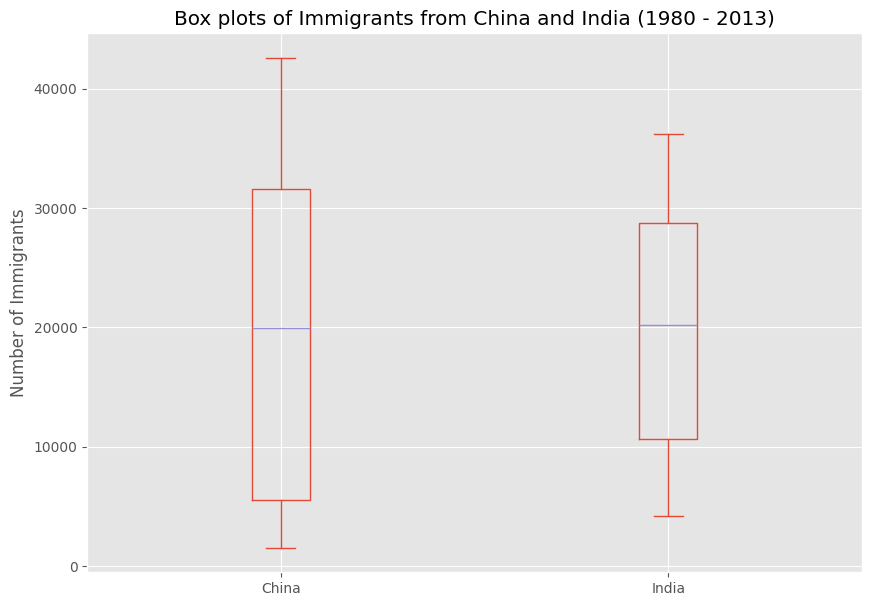

For a horizontal view: (set **vert=False**)

[output not shown]

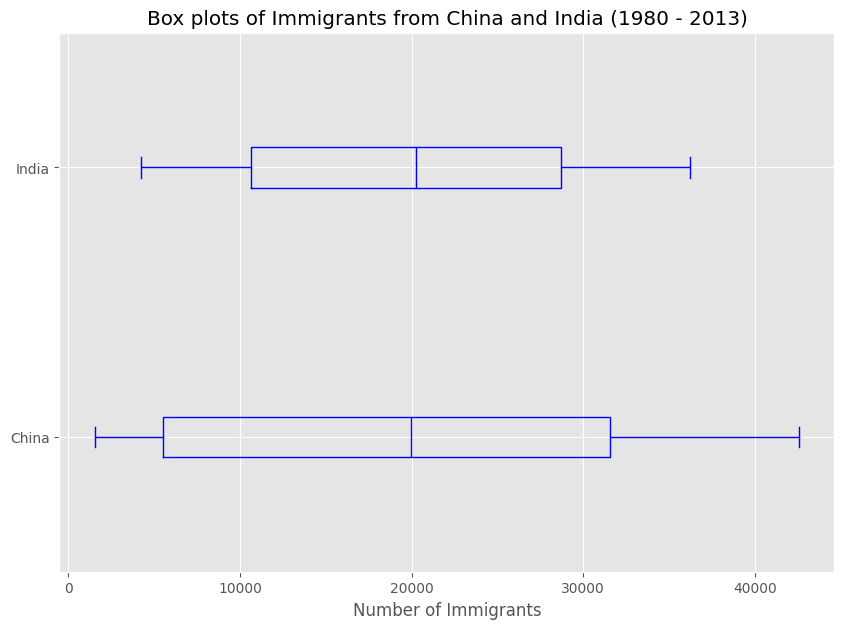

**Result:** The same comparison flipped horizontally - useful when country names are long.

### Subplots: Box Plot + Line Plot Side by Side

**Subplots** let us compare **multiple visualizations** in one figure. **Artist layer (ax.)** is usually used with **subplots**.

[figure not shown]

```
fig = plt.figure() # create figure

# ax = fig.add_subplot(nrows, ncols, plot_number)
ax0 = fig.add_subplot(1, 2, 1) # Tip: subplot(211) == subplot(2, 1, 1)
ax1 = fig.add_subplot(1, 2, 2)

df_CI.plot(kind='box', color='blue', vert=False, figsize=(20, 6), ax=ax0)
ax0.set_title('Box Plots of Immigrants from China and India (1980 - 2013)')
ax0.set_xlabel('Number of Immigrants')
ax0.set_ylabel('Countries')

df_CI.plot(kind='line', figsize=(20, 6), ax=ax1)
ax1.set_title('Line Plots of Immigrants from China and India (1980 - 2013)')
ax1.set_ylabel('Number of Immigrants')
ax1.set_xlabel('Years')
plt.show()
```

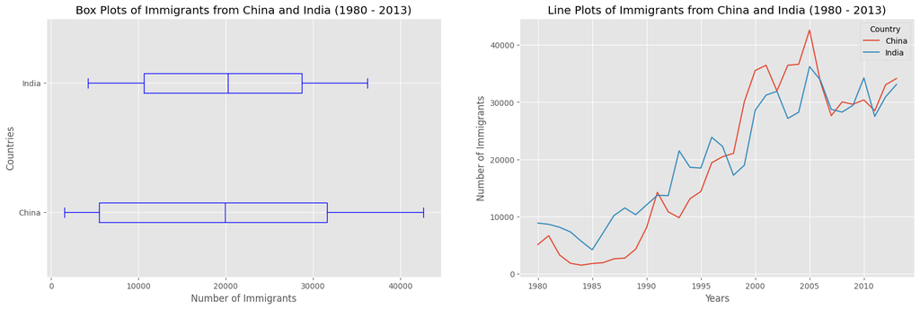

**Result:** A two-panel figure. The left panel shows box plots; the right panel shows the same data as time-series lines. The line plot reveals that China overtook India around the year 2000, and both show upward trends.

### Exercise: Top 15 Countries by Decade

**Goal:** Create box plots comparing the top 15 countries' immigration totals across the 1980s, 1990s, and 2000s.

**Step 1:** Get the top 15 countries by total immigration.

```
df_top15 = df_can.sort_values(['Total'], ascending=False, axis=0).head(15)
df_top15.head()
```

| Country | Continent | Region | DevName | 1980 | 1981 | 1982 | 1983 | 1984 | 1985 | 1986 | ... | 2005 | 2006 | 2007 | 2008 | 2009 | 2010 | 2011 | 2012 | 2013 | Total |
| --- | --- | --- | --- | --- | --- | --- | --- | --- | --- | --- | --- | --- | --- | --- | --- | --- | --- | --- | --- | --- | --- |
| India | Asia | Southern Asia | Developing regions | 8880 | 8670 | 8147 | 7338 | 5704 | 4211 | 7150 | ... | 36210 | 33848 | 28742 | 28261 | 29456 | 34235 | 27509 | 30933 | 33087 | 691904 |
| China | Asia | Eastern Asia | Developing regions | 5123 | 6682 | 3308 | 1863 | 1527 | 1816 | 1960 | ... | 42584 | 33518 | 27642 | 30037 | 29622 | 30391 | 28502 | 33024 | 34129 | 659962 |
| United Kingdom of Great Britain and Northern Ireland | Europe | Northern Europe | Developed regions | 22045 | 24796 | 20620 | 10015 | 10170 | 9564 | 9470 | ... | 7258 | 7140 | 8216 | 8979 | 8876 | 8724 | 6204 | 6195 | 5827 | 551500 |
| Philippines | Asia | South-Eastern Asia | Developing regions | 6051 | 5921 | 5249 | 4562 | 3801 | 3150 | 4166 | ... | 18139 | 18400 | 19837 | 24887 | 28573 | 38617 | 36765 | 34315 | 29544 | 511391 |
| Pakistan | Asia | Southern Asia | Developing regions | 978 | 972 | 1201 | 900 | 668 | 514 | 691 | ... | 14314 | 13127 | 10124 | 8994 | 7217 | 6811 | 7468 | 11227 | 12603 | 241600 |

5 rows × 38 columns

**Step 2:** Aggregate totals by decade.

```
# create a list of all years in decades 80's, 90's, and 00's
years_80s = list(map(str, range(1980, 1990)))
years_90s = list(map(str, range(1990, 2000)))
years_00s = list(map(str, range(2000, 2010)))

# create a series for each decade
df_80s = df_top15.loc[:, years_80s].sum(axis=1)
df_90s = df_top15.loc[:, years_90s].sum(axis=1)
df_00s = df_top15.loc[:, years_00s].sum(axis=1)

# merge the three series into a new data frame
new_df = pd.DataFrame({'1980s': df_80s, '1990s': df_90s, '2000s': df_00s})
new_df.head()
```

| Country | 1980s | 1990s | 2000s |
| --- | --- | --- | --- |
| India | 82154 | 180395 | 303591 |
| China | 32003 | 161528 | 340385 |
| United Kingdom of Great Britain and Northern Ireland | 179171 | 261966 | 83413 |
| Philippines | 60764 | 138482 | 172904 |
| Pakistan | 10591 | 65302 | 127598 |

**Step 3:** Plot the box plots.

```
new_df.plot(kind='box', figsize=(10, 6))
plt.title('Immigration from top 15 countries for decades 80s, 90s and 2000s')
plt.show()
```

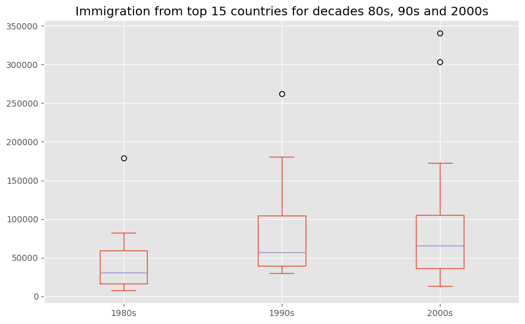

```
new_df.describe()
```

|  | 1980s | 1990s | 2000s |
| --- | --- | --- | --- |
| count | 15.000000 | 15.000000 | 15.000000 |
| mean | 44418.333333 | 85594.666667 | 97471.533333 |
| std | 44190.676455 | 68237.560246 | 100583.204205 |
| min | 7613.000000 | 30028.000000 | 13629.000000 |
| 25% | 16698.000000 | 39259.000000 | 36101.500000 |
| 50% | 30638.000000 | 56915.000000 | 65794.000000 |
| 75% | 59183.000000 | 104451.500000 | 105505.500000 |
| max | 179171.000000 | 261966.000000 | 340385.000000 |

The box plot differs from the summary table created. The box plot scans the data and identifies the outliers. In order to be an outlier, the data value must be:

- larger than Q3 by at least 1.5 times the interquartile range (IQR), or,
- smaller than Q1 by at least 1.5 times the IQR.

Let's look at decade 2000s as an example:

- Q1 (25%) = 36,101.5
- Q3 (75%) = 105,505.5
- **IQR = Q3 - Q1** = 69,404

Using the definition of outlier, any value that is greater than Q3 by 1.5 times IQR will be flagged as outlier.

Outlier > 105,505.5 + (1.5 * 69,404)  
Outlier > 209,611.5

Let's confirm:

```
new_df = new_df.reset_index()
new_df[new_df['2000s'] > 209611.5]
```

|  | Country | 1980s | 1990s | 2000s |
| --- | --- | --- | --- | --- |
| 0 | India | 82154 | 180395 | 303591 |
| 1 | China | 32003 | 161528 | 340385 |

China and India stand out because their immigration totals are **disproportionately large** (exceeds 209,611.5 for the decade) compared to the rest of the dataset.

Refer to [Matplotlib documentation](https://matplotlib.org/3.1.1/api/_as_gen/matplotlib.pyplot.boxplot.html) on box plots for more information.

## 5. Scatter Plots

A scatter plot **maps two variables on a 2D graph** without connecting the points. It's **perfect for spotting trends and relationships**.

Let's visualize total immigration to Canada across all countries for each year from 1980 to 2013.

**Step 1:** Get the total population per year.

```
df_tot = pd.DataFrame(df_can[years].sum(axis=0)) # total population
df_tot.index = map(int, df_tot.index) # for regression later on
df_tot.reset_index(inplace=True)
df_tot.columns = ['year', 'total']
df_tot.head()
```

|  | year | total |
| --- | --- | --- |
| 0 | 1980 | 99137 |
| 1 | 1981 | 110563 |
| 2 | 1982 | 104271 |
| 3 | 1983 | 75550 |
| 4 | 1984 | 73417 |

**Step 2:** Generate the scatter plot.

```
df_tot.plot(kind='scatter', x='year', y='total', figsize=(10, 6), color='darkblue')
plt.title('Total Immigration to Canada from 1980 - 2013')
plt.xlabel('Year')
plt.ylabel('Number of Immigrants')
plt.show()
```

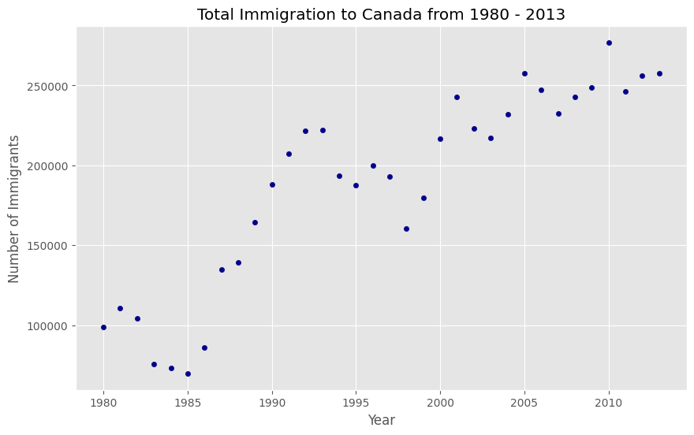

### Adding a Regression Line

Then fit a **linear regression line** to quantify the trend using Numpy's **polyfit()**

```
x = df_tot['year']
y = df_tot['total']
#Degree of fitting polynomial. 1 = linear, 2 = quadratic, and so on.
fit = np.polyfit(x, y, deg=1)
fit
```

```
array([ 5.56709228e+03, -1.09261952e+07])
```

The **slope** is **~5,567** and the **intercept** is **~ -10,926,195**. This gives the equation: **Immigrants = 5,567 × Year − 10,926,195**.

```
df_tot.plot(kind='scatter', x='year', y='total', figsize=(10, 6), color='darkblue')
plt.title('Total Immigration to Canada from 1980 - 2013')
plt.xlabel('Year')
plt.ylabel('Number of Immigrants')
plt.plot(x, fit[0] * x + fit[1], color='red')
plt.annotate('y={0:.0f} x + {1:.0f}'.format(fit[0], fit[1]), xy=(2000, 150000))
plt.show()

'No. Immigrants = {0:.0f} * Year + {1:.0f}'.format(fit[0], fit[1])
```

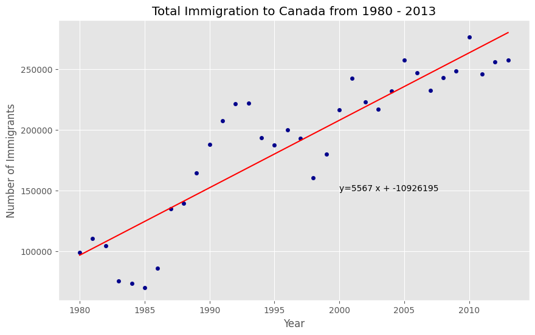

```
'No. Immigrants = 5567 * Year + -10926195'
```

**Result:** Red regression line across data points. Immigration **took a dip around 1993 - 1997** due to **Bill C-86** making it more difficult for family members (other than nuclear family) to immigrate to Canada.

Using the equation of line of best fit, the number of immigrants in 2015 can be estimated:

```
No. Immigrants = 5567 * Year - 10926195
No. Immigrants = 5567 * 2015 - 10926195
No. Immigrants = 291,310
```

When compared to the actual from Citizenship and Immigration Canada's (CIC) 2016 Annual Report, Canada accepted **271,845** immigrants in 2015, **7% off from the estimation** - a solid estimate given the data source.

### Exercise: Denmark, Norway, and Sweden

**Goal:** Create a scatter plot showing total immigration from Denmark, Norway, and Sweden combined.

```
df_countries = df_can.loc[['Denmark', 'Norway', 'Sweden'], years].transpose()
df_total = pd.DataFrame(df_countries.sum(axis=1))
df_total.reset_index(inplace=True)
df_total.columns = ['year', 'total']
df_total['year'] = df_total['year'].astype(int)
df_total.head()
```

|  | year | total |
| --- | --- | --- |
| 0 | 1980 | 669 |
| 1 | 1981 | 678 |
| 2 | 1982 | 627 |
| 3 | 1983 | 333 |
| 4 | 1984 | 252 |

```
df_total.plot(kind='scatter', x='year', y='total', figsize=(10, 6), color='darkblue')
plt.title('Immigration from Denmark, Norway, and Sweden to Canada from 1980 - 2013')
plt.xlabel('Year')
plt.ylabel('Number of Immigrants')
plt.show()
```

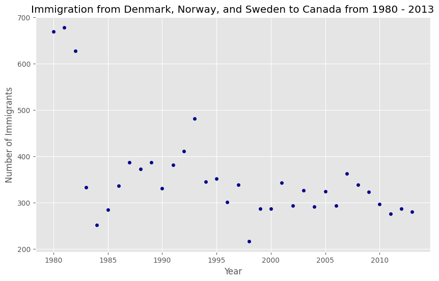

**Result:** A scatter plot showing a generally declining trend. Immigration from these Scandinavian countries has decreased over time.

## 6. Bubble Plots

A **bubble plot** extends the scatter plot by adding a third dimension: the **size** of each bubble represents a third variable (the **"weight**").

I'll use this to analyze immigration from **Argentina** and **Brazil** and see how economic crises affected emigration.

**Step 1:** Prepare a transposed dataframe with years as integers.

```
df_can_t = df_can[years].transpose()
df_can_t.index = map(int, df_can_t.index)
df_can_t.index.name = 'Year'
df_can_t.reset_index(inplace=True)
df_can_t.head()
```

| Country | Year | Afghanistan | Albania | Algeria | American Samoa | Andorra | Angola | Antigua and Barbuda | Argentina | Armenia | ... | United States of America | Uruguay | Uzbekistan | Vanuatu | Venezuela (Bolivarian Republic of) | Viet Nam | Western Sahara | Yemen | Zambia | Zimbabwe |
| --- | --- | --- | --- | --- | --- | --- | --- | --- | --- | --- | --- | --- | --- | --- | --- | --- | --- | --- | --- | --- | --- |
| 0 | 1980 | 16 | 1 | 80 | 0 | 0 | 1 | 0 | 368 | 0 | ... | 9378 | 128 | 0 | 0 | 103 | 1191 | 0 | 1 | 11 | 72 |
| 1 | 1981 | 39 | 0 | 67 | 1 | 0 | 3 | 0 | 426 | 0 | ... | 10030 | 132 | 0 | 0 | 117 | 1829 | 0 | 2 | 17 | 114 |
| 2 | 1982 | 39 | 0 | 71 | 0 | 0 | 6 | 0 | 626 | 0 | ... | 9074 | 146 | 0 | 0 | 174 | 2162 | 0 | 1 | 11 | 102 |
| 3 | 1983 | 47 | 0 | 69 | 0 | 0 | 6 | 0 | 241 | 0 | ... | 7100 | 105 | 0 | 0 | 124 | 3404 | 0 | 6 | 7 | 44 |
| 4 | 1984 | 71 | 0 | 63 | 0 | 0 | 4 | 42 | 237 | 0 | ... | 6661 | 90 | 0 | 0 | 142 | 7583 | 0 | 0 | 16 | 32 |

5 rows × 196 columns

**Step 2:** Normalize the data for bubble size using **min-max scaling** (values 0–1). The general formula is:

[figure not shown]

where $X$ is the original value, $X'$ is the corresponding normalized value. The formula sets the max value in the dataset to 1, and sets the min value to 0. The rest of the data points are scaled to a value between 0-1 accordingly.

```
norm_brazil = (df_can_t['Brazil'] - df_can_t['Brazil'].min()) / (df_can_t['Brazil'].max() - df_can_t['Brazil'].min())
norm_argentina = (df_can_t['Argentina'] - df_can_t['Argentina'].min()) / (df_can_t['Argentina'].max() - df_can_t['Argentina'].min())
```

**Step 3:** Plot the bubble chart.

```
# Brazil
ax0 = df_can_t.plot(
    kind='scatter',
    x='Year',
    y='Brazil',
    figsize=(14, 8),
    alpha=0.5,
    color='green',
    s=norm_brazil * 2000 + 10, # upscale for visibility and
    xlim=(1975, 2015)
)
# Argentina
ax1 = df_can_t.plot(
    kind='scatter',
    x='Year',
    y='Argentina',
    alpha=0.5,
    color='blue',
    s=norm_argentina * 2000 + 10, # +10 for points with zero weights
    ax=ax0
)

ax0.set_ylabel('Number of Immigrants')
ax0.set_title('Immigration from Brazil and Argentina from 1980 to 2013')
ax0.legend(['Brazil', 'Argentina'], loc='upper left', fontsize='x-large')
plt.show()
```

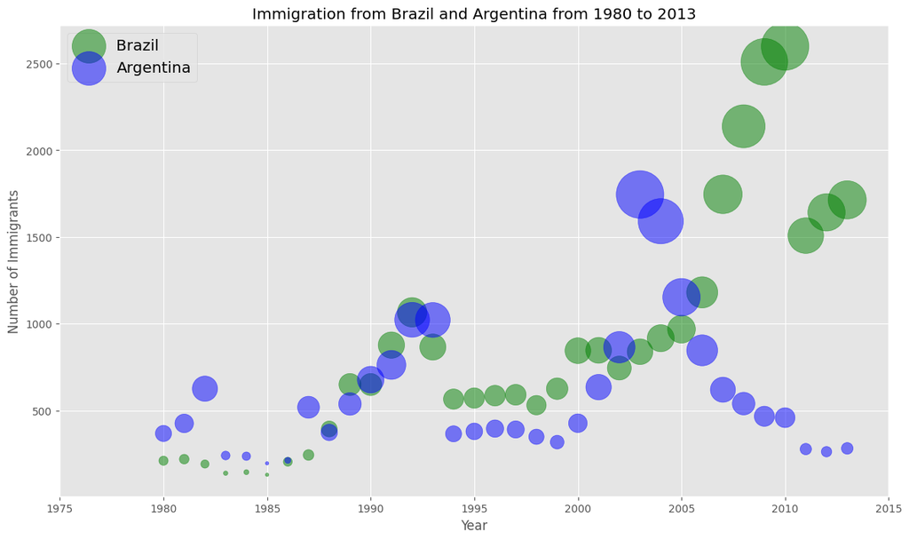

**Result:** A bubble plot where bubble **size reflects the relative magnitude of immigration** for each year. **Key observations**:

- Argentina shows a spike in immigration during its **1998–2002 great depression** (larger bubbles).
- Another spike appears around **1985–1993**, corresponding to an earlier economic downturn.
- Brazil shows a surge around **2010**, following the recovery from the Samba Effect currency crisis of 1999.

### Exercise: China vs. India Bubble Plot

**Goal:** Create a bubble plot comparing immigration from China and India.

**Step 1:** Normalize the data.

```
norm_china = (df_can_t['China'] - df_can_t['China'].min()) / (df_can_t['China'].max() - df_can_t['China'].min())
norm_india = (df_can_t['India'] - df_can_t['India'].min()) / (df_can_t['India'].max() - df_can_t['India'].min())
```

Step 2: Generate the bubble plots.

```
ax0 = df_can_t.plot(
    kind='scatter',
    x='Year',
    y='China',
    figsize=(14, 8),
    alpha=0.5,
    color='green',
    s=norm_china * 2000 + 10,
    xlim=(1975, 2015)
)

ax1 = df_can_t.plot(
    kind='scatter',
    x='Year',
    y='India',
    alpha=0.5,
    color='blue',
    s=norm_india * 2000 + 10,
    ax=ax0
)

ax0.set_ylabel('Number of Immigrants')
ax0.set_title('Immigration from China and India from 1980 - 2013')
ax0.legend(['China', 'India'], loc='upper left', fontsize='x-large')
plt.show()
```

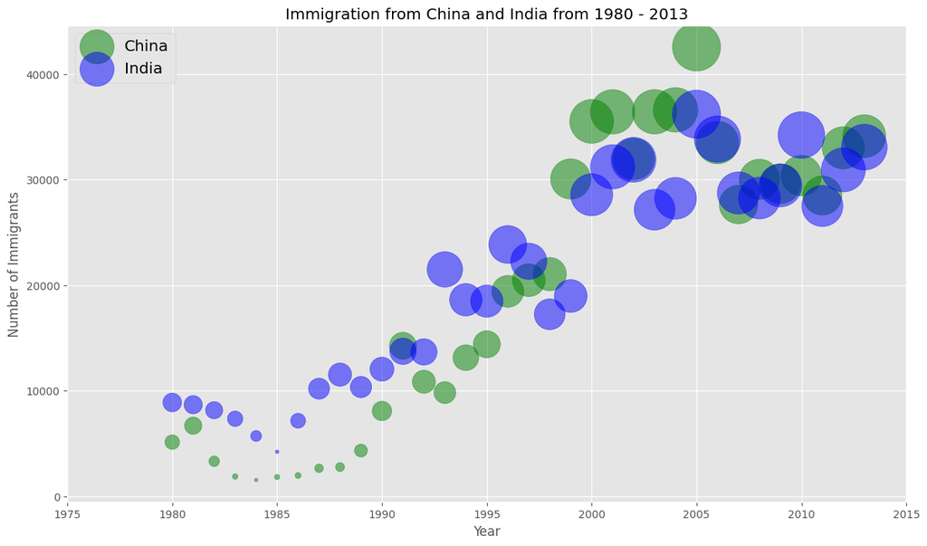

**Result:** Both countries show growing bubbles over time, with China overtaking India around 2000. Bubble sizes make the trend visible without connecting lines.

That's the full walkthrough. I prepared the dataset, grouped and aggregated with pandas, and built four Matplotlib plots - **pie**, **box**, **scatter**, and **bubble** and **run a regression** forecast.